# PYTHON CAC-2

# Exploratory Data Analysis

The team must identify a Domain related to Lavasa (Student Life, Traveling Preferences, Food Preferences...), create a unique problem statement associated with the domain, and determine the attributes associated with the problem.

Collect data using various techniques, perform Exploratory Data Analysis (with the help of Python), and Present the Key insights obtained from the analysis in a Chart.

DOMAIN:- STUDENT'S LIFE IN THE COLLEGE CAMPUS

PROBLEM:- MANAGEMENT BETWEEN ACADEMICS AND EXTRA CURRICULAR

Install Python Libraries

```python
# pip install pandas
```

```python
# pip install numpy
```

```python
# pip install matplotlib
```

IMPORT PYTHON LIBRARIES

Pandas and Numpy have been used for Data Manipulation and Numerical Calculations

Matplotlib and Seaborn have been used for Data visualizations.

```python
import pandas as pd
import numpy as np
import matplotlib.pyplot as plt
import seaborn as sns
```

READING THE DATASET

```python
#READING THE DATASET
pd.read_excel("Students' Life at Christ (Responses).xlsx")
```

|  | Timestamp | Name | Department | GENDER | YEAR | Do you follow a Semester or Trimester System? | Do you participate in any extra curricular activities? | If No, how do you spend your time after college hours? | IF YES, select the following | Are you able to balance your academics with extracurricular? | How do you rate your time management\n(On the scale of 5) | Do you think participation in extracurricular affect your academic performance? | Do you think extracurricular activities should be open after 10:30? | Do you think everyone is getting equal chance in participating in extracurricular activities? | Do you get exposure in extracurricular activities | If yes, select one of the following | If No, select the reason |
| --- | --- | --- | --- | --- | --- | --- | --- | --- | --- | --- | --- | --- | --- | --- | --- | --- | --- |
| 0 | 2023-10-10 21:20:21.933 | Stuty Das | MSC DS | FEMALE | FIRST | Trimester | No | Cooking | NaN | NaN | 4 | Yes | Maybe | Maybe | NaN | NaN | Hectic Academic schedule |
| 1 | 2023-10-10 21:32:57.896 | Aryan Manchanda | BSC DS | MALE | FIRST | Semester | YES | NaN | SPORTS | No | 3 | Maybe | Yes | Yes | Yes | Proper Training | NaN |
| 2 | 2023-10-10 22:16:09.915 | Anju Mathew | LLB | FEMALE | SECOND | Semester | YES | NaN | SWO | Yes | 4 | Maybe | No | Yes | Yes | Good facilities | NaN |
| 3 | 2023-10-10 22:17:36.971 | Gracy Rathaur | LLB | FEMALE | THIRD | Semester | YES | NaN | CLUBS | Maybe | 3 | Yes | No | Yes | Yes | Good facilities | NaN |
| 4 | 2023-10-10 22:35:12.016 | Sreelakshmi G | BBA | FEMALE | FIRST | Semester | No | Academic works | NaN | NaN | 3 | Maybe | Maybe | NaN | NaN | NaN | Hectic Academic schedule |
| ... | ... | ... | ... | ... | ... | ... | ... | ... | ... | ... | ... | ... | ... | ... | ... | ... | ... |
| 397 | 2023-10-17 22:30:13.221 | Rhea Eleanor Rhine | BBA | FEMALE | THIRD | Semester | No | Hang out with friends | NaN | Maybe | 3 | No | Yes | No | No | NaN | Lack of facilities |
| 398 | 2023-10-17 22:31:36.111 | Pariska Nagvenkar | BBA | FEMALE | SECOND | Semester | No | Academic works | NaN | No | 3 | Yes | Maybe | Yes | No | NaN | Hectic Academic schedule |
| 399 | 2023-10-17 22:33:12.435 | Vatsal Sharma | LLB | MALE | SECOND | Semester | YES | NaN | CLUBS | Maybe | 3 | Yes | No | Yes | Yes | Good facilities | NaN |
| 400 | 2023-10-17 22:33:20.940 | Rachel | MBA | FEMALE | FIRST | Trimester | YES | NaN | SWO | Maybe | 2 | Maybe | No | Yes | Yes | Proper Training | NaN |
| 401 | 2023-10-17 22:34:02.656 | Shilpi Singh | BCOM | FEMALE | SECOND | Semester | No | Cooking | NaN | NaN | 3 | Maybe | Maybe | No | Maybe | NaN | NaN |

402 rows × 17 columns

```python
data = pd.read_excel("Students' Life at Christ (Responses).xlsx")
```

DATA CLEANING

```python
data["GENDER"].replace({"Male": "MALE", "Female": "FEMALE","FeMALE":"FEMALE"}, inplace=True)
```

ANALYZING THE DATASET

```python
data.dtypes
```

```
Timestamp                                                                                        datetime64[ns]
Name                                                                                                     object
Department                                                                                               object
GENDER                                                                                                   object
YEAR                                                                                                     object
Do you follow a Semester or Trimester System?                                                            object
Do you participate in any extra curricular activities?                                                   object
If No,  how do you spend your time after college hours?                                                  object
IF YES, select the following                                                                             object
Are you able to balance your academics with extracurricular?                                             object
How do you rate your time management\n(On the scale of 5)                                                 int64
Do you think participation in extracurricular affect your academic performance?                          object
Do you think extracurricular activities should be open after 10:30?                                      object
Do you think everyone is getting equal chance in participating in extracurricular activities?            object
Do you get exposure in extracurricular activities                                                        object
If yes, select one of the following                                                                      object
If No, select the reason                                                                                 object
dtype: object
```

```python
data.count()
```

```
Timestamp                                                                                        402
Name                                                                                             402
Department                                                                                       402
GENDER                                                                                           402
YEAR                                                                                             402
Do you follow a Semester or Trimester System?                                                    402
Do you participate in any extra curricular activities?                                           402
If No,  how do you spend your time after college hours?                                          235
IF YES, select the following                                                                     227
Are you able to balance your academics with extracurricular?                                     368
How do you rate your time management\n(On the scale of 5)                                        402
Do you think participation in extracurricular affect your academic performance?                  398
Do you think extracurricular activities should be open after 10:30?                              398
Do you think everyone is getting equal chance in participating in extracurricular activities?    394
Do you get exposure in extracurricular activities                                                381
If yes, select one of the following                                                              217
If No, select the reason                                                                         226
dtype: int64
```

```python
#DISPLAYING THE TOP 5 OBSERVATION
data.head()
```

|  | Timestamp | Name | Department | GENDER | YEAR | Do you follow a Semester or Trimester System? | Do you participate in any extra curricular activities? | If No, how do you spend your time after college hours? | IF YES, select the following | Are you able to balance your academics with extracurricular? | How do you rate your time management\n(On the scale of 5) | Do you think participation in extracurricular affect your academic performance? | Do you think extracurricular activities should be open after 10:30? | Do you think everyone is getting equal chance in participating in extracurricular activities? | Do you get exposure in extracurricular activities | If yes, select one of the following | If No, select the reason |
| --- | --- | --- | --- | --- | --- | --- | --- | --- | --- | --- | --- | --- | --- | --- | --- | --- | --- |
| 0 | 2023-10-10 21:20:21.933 | Stuty Das | MSC DS | FEMALE | FIRST | Trimester | No | Cooking | NaN | NaN | 4 | Yes | Maybe | Maybe | NaN | NaN | Hectic Academic schedule |
| 1 | 2023-10-10 21:32:57.896 | Aryan Manchanda | BSC DS | MALE | FIRST | Semester | YES | NaN | SPORTS | No | 3 | Maybe | Yes | Yes | Yes | Proper Training | NaN |
| 2 | 2023-10-10 22:16:09.915 | Anju Mathew | LLB | FEMALE | SECOND | Semester | YES | NaN | SWO | Yes | 4 | Maybe | No | Yes | Yes | Good facilities | NaN |
| 3 | 2023-10-10 22:17:36.971 | Gracy Rathaur | LLB | FEMALE | THIRD | Semester | YES | NaN | CLUBS | Maybe | 3 | Yes | No | Yes | Yes | Good facilities | NaN |
| 4 | 2023-10-10 22:35:12.016 | Sreelakshmi G | BBA | FEMALE | FIRST | Semester | No | Academic works | NaN | NaN | 3 | Maybe | Maybe | NaN | NaN | NaN | Hectic Academic schedule |

```python
#DISPLAYING THE LAST 5 OBSERVATION
data.tail()
```

|  | Timestamp | Name | Department | GENDER | YEAR | Do you follow a Semester or Trimester System? | Do you participate in any extra curricular activities? | If No, how do you spend your time after college hours? | IF YES, select the following | Are you able to balance your academics with extracurricular? | How do you rate your time management\n(On the scale of 5) | Do you think participation in extracurricular affect your academic performance? | Do you think extracurricular activities should be open after 10:30? | Do you think everyone is getting equal chance in participating in extracurricular activities? | Do you get exposure in extracurricular activities | If yes, select one of the following | If No, select the reason |
| --- | --- | --- | --- | --- | --- | --- | --- | --- | --- | --- | --- | --- | --- | --- | --- | --- | --- |
| 397 | 2023-10-17 22:30:13.221 | Rhea Eleanor Rhine | BBA | FEMALE | THIRD | Semester | No | Hang out with friends | NaN | Maybe | 3 | No | Yes | No | No | NaN | Lack of facilities |
| 398 | 2023-10-17 22:31:36.111 | Pariska Nagvenkar | BBA | FEMALE | SECOND | Semester | No | Academic works | NaN | No | 3 | Yes | Maybe | Yes | No | NaN | Hectic Academic schedule |
| 399 | 2023-10-17 22:33:12.435 | Vatsal Sharma | LLB | MALE | SECOND | Semester | YES | NaN | CLUBS | Maybe | 3 | Yes | No | Yes | Yes | Good facilities | NaN |
| 400 | 2023-10-17 22:33:20.940 | Rachel | MBA | FEMALE | FIRST | Trimester | YES | NaN | SWO | Maybe | 2 | Maybe | No | Yes | Yes | Proper Training | NaN |
| 401 | 2023-10-17 22:34:02.656 | Shilpi Singh | BCOM | FEMALE | SECOND | Semester | No | Cooking | NaN | NaN | 3 | Maybe | Maybe | No | Maybe | NaN | NaN |

```python
#DISPLAYING THE DATA TYPE AND THE INFORMATION ABOUT THE DATA SET
data.info()
```

```
<class 'pandas.core.frame.DataFrame'>
RangeIndex: 402 entries, 0 to 401
Data columns (total 17 columns):
 #   Column                                                                                         Non-Null Count  Dtype
---  ------                                                                                         --------------  -----
 0   Timestamp                                                                                      402 non-null    datetime64[ns]
 1   Name                                                                                           402 non-null    object
 2   Department                                                                                     402 non-null    object
 3   GENDER                                                                                         402 non-null    object
 4   YEAR                                                                                           402 non-null    object
 5   Do you follow a Semester or Trimester System?                                                  402 non-null    object
 6   Do you participate in any extra curricular activities?                                         402 non-null    object
 7   If No,  how do you spend your time after college hours?                                        235 non-null    object
 8   IF YES, select the following                                                                   227 non-null    object
 9   Are you able to balance your academics with extracurricular?                                   368 non-null    object
 10  How do you rate your time management
(On the scale of 5)                                       402 non-null    int64
 11  Do you think participation in extracurricular affect your academic performance?                398 non-null    object
 12  Do you think extracurricular activities should be open after 10:30?                            398 non-null    object
 13  Do you think everyone is getting equal chance in participating in extracurricular activities?  394 non-null    object
 14  Do you get exposure in extracurricular activities                                              381 non-null    object
 15  If yes, select one of the following                                                            217 non-null    object
 16  If No, select the reason                                                                       226 non-null    object
dtypes: datetime64[ns](1), int64(1), object(15)
memory usage: 53.5+ KB
```

```python
#CHECKING THE DUPLICATION
data.nunique()
```

```
Timestamp                                                                                        402
Name                                                                                             402
Department                                                                                        11
GENDER                                                                                             2
YEAR                                                                                               5
Do you follow a Semester or Trimester System?                                                      2
Do you participate in any extra curricular activities?                                             2
If No,  how do you spend your time after college hours?                                            4
IF YES, select the following                                                                       5
Are you able to balance your academics with extracurricular?                                       3
How do you rate your time management\n(On the scale of 5)                                          5
Do you think participation in extracurricular affect your academic performance?                    3
Do you think extracurricular activities should be open after 10:30?                                3
Do you think everyone is getting equal chance in participating in extracurricular activities?      3
Do you get exposure in extracurricular activities                                                  3
If yes, select one of the following                                                                3
If No, select the reason                                                                           5
dtype: int64
```

```python
#MISSING VALUE CALCULATION
data.isnull().sum()
```

```
Timestamp                                                                                          0
Name                                                                                               0
Department                                                                                         0
GENDER                                                                                             0
YEAR                                                                                               0
Do you follow a Semester or Trimester System?                                                      0
Do you participate in any extra curricular activities?                                             0
If No,  how do you spend your time after college hours?                                          167
IF YES, select the following                                                                     175
Are you able to balance your academics with extracurricular?                                      34
How do you rate your time management\n(On the scale of 5)                                          0
Do you think participation in extracurricular affect your academic performance?                    4
Do you think extracurricular activities should be open after 10:30?                                4
Do you think everyone is getting equal chance in participating in extracurricular activities?      8
Do you get exposure in extracurricular activities                                                 21
If yes, select one of the following                                                              185
If No, select the reason                                                                         176
dtype: int64
```

```python
#PERCENTAGE OF MISSING VALUE CALCULATION
data.isnull().sum()/(len(data))*100
```

```
Timestamp                                                                                         0.000000
Name                                                                                              0.000000
Department                                                                                        0.000000
GENDER                                                                                            0.000000
YEAR                                                                                              0.000000
Do you follow a Semester or Trimester System?                                                     0.000000
Do you participate in any extra curricular activities?                                            0.000000
If No,  how do you spend your time after college hours?                                          41.542289
IF YES, select the following                                                                     43.532338
Are you able to balance your academics with extracurricular?                                      8.457711
How do you rate your time management\n(On the scale of 5)                                         0.000000
Do you think participation in extracurricular affect your academic performance?                   0.995025
Do you think extracurricular activities should be open after 10:30?                               0.995025
Do you think everyone is getting equal chance in participating in extracurricular activities?     1.990050
Do you get exposure in extracurricular activities                                                 5.223881
If yes, select one of the following                                                              46.019900
If No, select the reason                                                                         43.781095
dtype: float64
```

Statistics Summary

```python
data.describe()
```

|  | How do you rate your time management\n(On the scale of 5) |
| --- | --- |
| count | 402.000000 |
| mean | 2.845771 |
| std | 0.856889 |
| min | 1.000000 |
| 25% | 2.000000 |
| 50% | 3.000000 |
| 75% | 3.000000 |
| max | 5.000000 |

```python
data.describe(include="all")
```

|  | Timestamp | Name | Department | GENDER | YEAR | Do you follow a Semester or Trimester System? | Do you participate in any extra curricular activities? | If No, how do you spend your time after college hours? | IF YES, select the following | Are you able to balance your academics with extracurricular? | How do you rate your time management\n(On the scale of 5) | Do you think participation in extracurricular affect your academic performance? | Do you think extracurricular activities should be open after 10:30? | Do you think everyone is getting equal chance in participating in extracurricular activities? | Do you get exposure in extracurricular activities | If yes, select one of the following | If No, select the reason |
| --- | --- | --- | --- | --- | --- | --- | --- | --- | --- | --- | --- | --- | --- | --- | --- | --- | --- |
| count | 402 | 402 | 402 | 402 | 402 | 402 | 402 | 235 | 227 | 368 | 402.000000 | 398 | 398 | 394 | 381 | 217 | 226 |
| unique | 402 | 402 | 11 | 2 | 5 | 2 | 2 | 4 | 5 | 3 | NaN | 3 | 3 | 3 | 3 | 3 | 5 |
| top | 2023-10-10 21:20:21.933000 | Stuty Das | LLB | MALE | FIRST | Semester | YES | Academic works | CLUBS | Maybe | NaN | Yes | Yes | Yes | Yes | Good facilities | Hectic Academic schedule |
| freq | 1 | 1 | 118 | 209 | 181 | 305 | 215 | 132 | 78 | 161 | NaN | 178 | 196 | 193 | 184 | 120 | 160 |
| first | 2023-10-10 21:20:21.933000 | NaN | NaN | NaN | NaN | NaN | NaN | NaN | NaN | NaN | NaN | NaN | NaN | NaN | NaN | NaN | NaN |
| last | 2023-10-17 22:34:02.656000 | NaN | NaN | NaN | NaN | NaN | NaN | NaN | NaN | NaN | NaN | NaN | NaN | NaN | NaN | NaN | NaN |
| mean | NaN | NaN | NaN | NaN | NaN | NaN | NaN | NaN | NaN | NaN | 2.845771 | NaN | NaN | NaN | NaN | NaN | NaN |
| std | NaN | NaN | NaN | NaN | NaN | NaN | NaN | NaN | NaN | NaN | 0.856889 | NaN | NaN | NaN | NaN | NaN | NaN |
| min | NaN | NaN | NaN | NaN | NaN | NaN | NaN | NaN | NaN | NaN | 1.000000 | NaN | NaN | NaN | NaN | NaN | NaN |
| 25% | NaN | NaN | NaN | NaN | NaN | NaN | NaN | NaN | NaN | NaN | 2.000000 | NaN | NaN | NaN | NaN | NaN | NaN |
| 50% | NaN | NaN | NaN | NaN | NaN | NaN | NaN | NaN | NaN | NaN | 3.000000 | NaN | NaN | NaN | NaN | NaN | NaN |
| 75% | NaN | NaN | NaN | NaN | NaN | NaN | NaN | NaN | NaN | NaN | 3.000000 | NaN | NaN | NaN | NaN | NaN | NaN |
| max | NaN | NaN | NaN | NaN | NaN | NaN | NaN | NaN | NaN | NaN | 5.000000 | NaN | NaN | NaN | NaN | NaN | NaN |

DISTRIBUTION

```
How do you rate your time management
(On the scale of 5)
Skew: -0.1
```

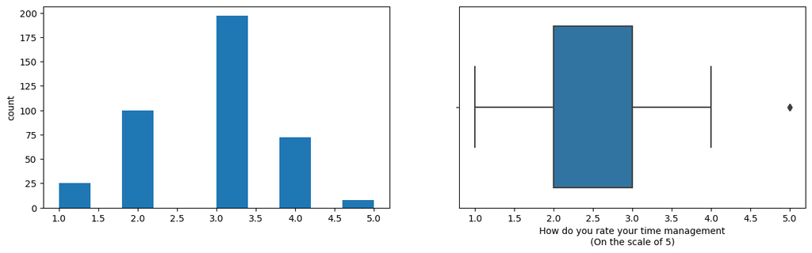

```python
#HISTROGRAM CHART FOR TIME MANAGEMENT
import numpy as np


for col in data.columns:
    if data[col].dtype in ['int64', 'float64']:  # Check if the data type is numerical
        print(col)
        print('Skew:', round(data[col].skew(), 2))
        plt.figure(figsize=(15, 4))
        plt.subplot(1, 2, 1)
        data[col].hist(grid=False)
        plt.ylabel('count')
        plt.subplot(1, 2, 2)
        sns.boxplot(x=data[col])
        plt.show()
```

From the graph above, we concluded that most of the students rate their time management skills as not so appropriate.

CATEGORICAL DISTRIBUTION

1.YEARWISE DISTRIBUTION

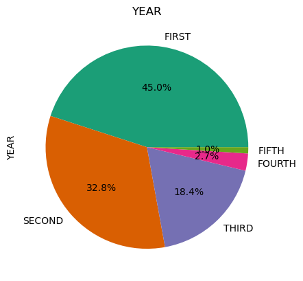

```python
#PIE CHART FOR YEARWISE DISTRIBUTION
import numpy as np

def categorical_histogram(df, colname, figscale=1, mpl_palette_name='Dark2'):
    from matplotlib import pyplot as plt
    import seaborn as sns
    group_counts = df[colname].value_counts()
    group_counts.plot(kind='pie', colors=sns.color_palette(mpl_palette_name), figsize=(8*figscale, 4.8*figscale), autopct='%1.1f%%')
    plt.gca().set_aspect("equal")  # Ensure the pie chart is a circle
    plt.title(colname)
    return

categorical_histogram(data, 'YEAR')
plt.show()
```

It is quite evident that the first years participation in the survey was the maximum as compared to the others, while students of fifth year were the least.

2.GENDERWISE DISTRIBUTION

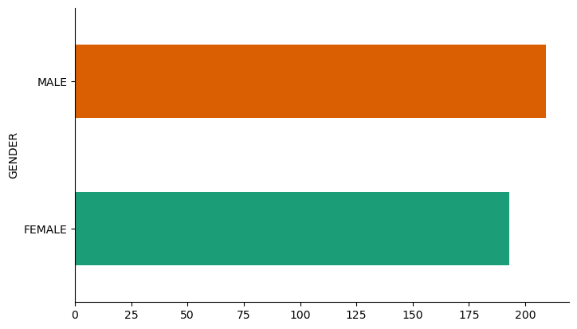

```python
import numpy as np

def categorical_histogram(df, colname, figscale=1, mpl_palette_name='Dark2'):
    from matplotlib import pyplot as plt
    import seaborn as sns
    df.groupby(colname).size().plot(kind='barh', color=sns.palettes.mpl_palette(mpl_palette_name), figsize=(8*figscale, 4.8*figscale))
    plt.gca().spines[['top', 'right',]].set_visible(False)
    return plt

chart = categorical_histogram(data, 'GENDER')
plt.show()  # Show the chart
```

Although, the participation from both males and females are impressive, but still responses from males have an upper edge in comparison to females.

3.TRIMESTERWISE/SEMESTERWISE DISTRIBUTION

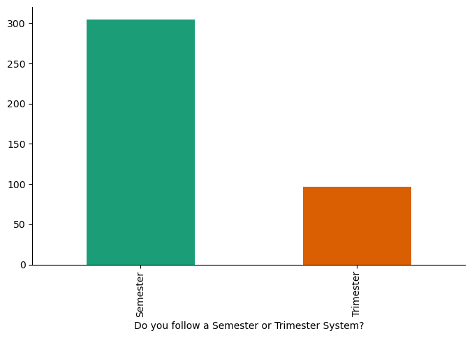

```python
import numpy as np

def categorical_histogram(df, colname, figscale=1, mpl_palette_name='Dark2'):
    from matplotlib import pyplot as plt
    import seaborn as sns
    df.groupby(colname).size().plot(kind='bar', color=sns.palettes.mpl_palette(mpl_palette_name), figsize=(8*figscale, 4.8*figscale))
    plt.gca().spines[['top', 'right',]].set_visible(False)
    return plt

chart = categorical_histogram(data, 'Do you follow a Semester or Trimester System?')
plt.show()  # Show the bar graph
```

It's clearly evident that most of the courses in Christ University has a semester based pattern.

4.PARTICIPATION IN EXTRA CURRICULAR ACTIVITIES

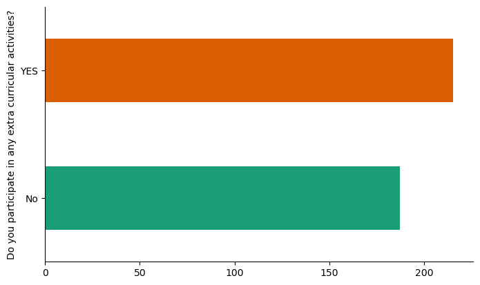

```python
import numpy as np


def categorical_histogram(df, colname, figscale=1, mpl_palette_name='Dark2'):
  from matplotlib import pyplot as plt
  import seaborn as sns
  df.groupby(colname).size().plot(kind='barh', color=sns.palettes.mpl_palette(mpl_palette_name), figsize=(8*figscale, 4.8*figscale))
  plt.gca().spines[['top', 'right',]].set_visible(False)
  return

chart = categorical_histogram(data, *['Do you participate in any extra curricular activities?'], **{})
chart
```

It's surprising to conclude that there is no significant difference between the no. students who partici[ate and not participate in extra curricular activities.]

1. SEMESTER/TRIMESTERWISE PARTICIPATION IN EXTRA-CURRICULAR ACTIVITIES

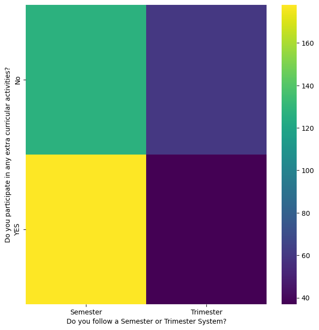

```python
import numpy as np

def heatmap(df, x_colname, y_colname, figscale=1, mpl_palette_name='viridis'):
  from matplotlib import pyplot as plt
  import seaborn as sns
  import pandas as pd
  plt.subplots(figsize=(8 * figscale, 8 * figscale))
  df_2dhist = pd.DataFrame({
      x_label: grp[y_colname].value_counts()
      for x_label, grp in df.groupby(x_colname)
  })
  sns.heatmap(df_2dhist, cmap=mpl_palette_name)
  plt.xlabel(x_colname)
  plt.ylabel(y_colname)
  return

chart = heatmap(data, *['Do you follow a Semester or Trimester System?', 'Do you participate in any extra curricular activities?'], **{})
chart
```

This heatmap indicates that the students that have trimesters are unable to participate in co-curricular activites while the semester students are actively participating in such activites, which indirectly hints at the insufficient time with the former students.

6.HEATMAP OF THE TRIMESTER/SEMESTER BASED ON YEARWISE

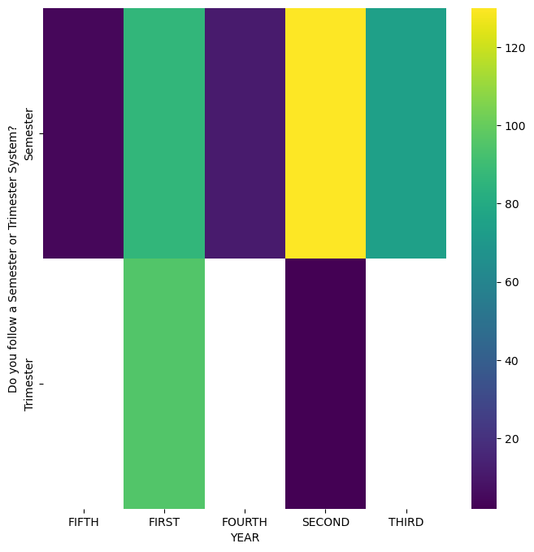

```python
import numpy as np

def heatmap(df, x_colname, y_colname, figscale=1, mpl_palette_name='viridis'):
  from matplotlib import pyplot as plt
  import seaborn as sns
  import pandas as pd
  plt.subplots(figsize=(8 * figscale, 8 * figscale))
  df_2dhist = pd.DataFrame({
      x_label: grp[y_colname].value_counts()
      for x_label, grp in df.groupby(x_colname)
  })
  sns.heatmap(df_2dhist, cmap=mpl_palette_name)
  plt.xlabel(x_colname)
  plt.ylabel(y_colname)
  return

chart = heatmap(data, *['YEAR', 'Do you follow a Semester or Trimester System?'], **{})
chart
```

This chart is segregating the semester/trimester depedending on the year the students are currently enrolled in. For instance: the third,fourth,fifth year don't have any trimesters.

7.HEATMAP OF THE YEARWISE BASED ON GENDER

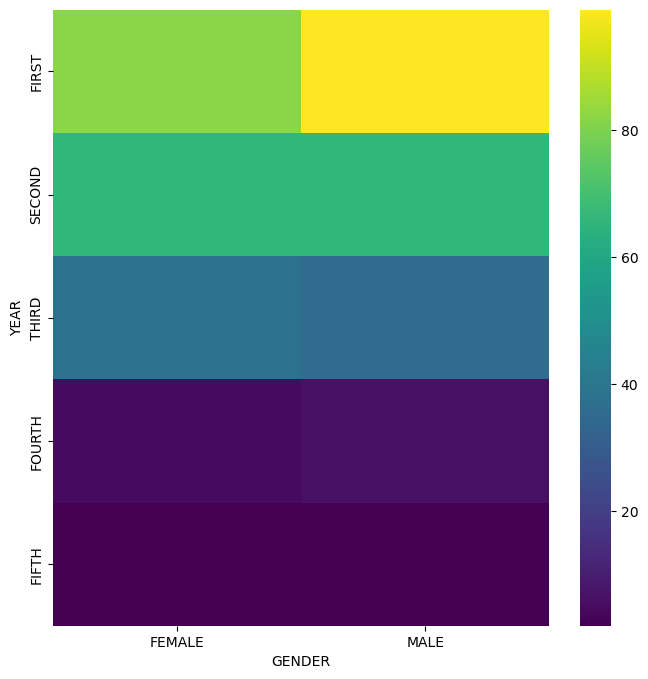

```python
import numpy as np

def heatmap(df, x_colname, y_colname, figscale=1, mpl_palette_name='viridis'):
  from matplotlib import pyplot as plt
  import seaborn as sns
  import pandas as pd
  plt.subplots(figsize=(8 * figscale, 8 * figscale))
  df_2dhist = pd.DataFrame({
      x_label: grp[y_colname].value_counts()
      for x_label, grp in df.groupby(x_colname)
  })
  sns.heatmap(df_2dhist, cmap=mpl_palette_name)
  plt.xlabel(x_colname)
  plt.ylabel(y_colname)
  return

chart = heatmap(data, *['GENDER', 'YEAR'], **{})
chart
```

Males from the first year have responded the most, while females from the fifth year have responded the least.